# Homework-1-2

## Homework 1-2: Introduction to Webscraping with BeautifulSoup

Sometimes the most interesting data sets don’t come with an API or pre-packaged plain-text CSVs. In these situations, web scraping can be a powerful tool, enabling us to extract and convert data from almost any format found on the internet into a tabular form we can conduct further analysis on.

For this section we will be working with historic population estimates of different US states listed on Wikipedia here:https://en.wikipedia.org/wiki/List_of_U.S._states_by_historical_population. In this section, you’ll learn how to import html-tables on the web into something you can manipulate with pandas.

Specifically, we will:

```
1. Download the relevant webpage as raw html with the requests library
2. Parse the html into a tree-like python-object with the BeautifulSoup library
3. Use BeautifulSoup to select and extract just the tables we’re interested in
4. Combine the tables, clean the text, and convert them into a single python dictionary
5. Make a pandas dataframe from the dictionary
6. Doing some basic analysis and plotting (with matplotlib)
```

As usual, our first step is to import the necessary libraries.

```python
import numpy as np
import scipy as sp
import matplotlib as mpl
import matplotlib.cm as cm
import matplotlib.pyplot as plt
import pandas as pd
pd.set_option('display.width', 500)
pd.set_option('display.max_columns', 100)
pd.set_option('display.notebook_repr_html', True)
import seaborn as sns
sns.set_style("whitegrid")
sns.set_context("poster")

# Two new
import requests
requests.packages.urllib3.disable_warnings()
#Requests enables us to download raw html as text
from bs4 import BeautifulSoup
# BeautifulSoup enables us to navigate html in python with dom-like tree structure

import warnings
warnings.filterwarnings('ignore')
```

## Step 1: Download the relevant webpage as raw html

```python
#url = "http://www.baidu.com"
url="https://en.wikipedia.org/wiki/List_of_U.S._states_by_historical_population"

r = requests.get(url, timeout=60,verify=False)
```

Always remember to “not to be evil” when scraping with requests! If downloading multiple pages, always put a delay between requests (e.g,, time.sleep(1), with the time library) so you don’t unwittingly hammer someone’s webserver and/or get blocked.

```python
raw_html = r.text
#raw_html
#print(raw_html)
```

Now, we have all our data in the notebook. Unfortunately, it is the form of one really long string, which is hard to work with directly. This is where BeautifulSoup comes in.

## Step 2: Parse the html with BeautifulSoup

```python
soup = BeautifulSoup(raw_html, 'html.parser')
```

Key BeautifulSoup functions we’ll be using in this section:

- **soup.prettify()**: Returns cleanedup version of raw html for printing
- **soup.find_all(,attrs=)**: Returns python list of matching objects
- **soup.find(,attrs=)**: Returns first matching object
- **soup.text/soup.get_text()**: Returns visible text of an object (e.g.,"`<p>Some text</p>`" -> "Some text")

BeautifulSoup is a very powerful library -- much more info here: https://www.crummy.com/software/BeautifulSoup/bs4/doc/

### Let's practice some BeautifulSoup commands..

**Print a cleanedup version of raw html for printing**

```python
# Your code here
#print(soup.prettify())
```

**Find the first “title” object**

```python
# Your code here
result = soup.find("title")
print(result)
```

```
<title>List of U.S. states and territories by historical population - Wikipedia</title>
```

**Find the text of first “title” object**

```python
# Your code here
print(result.text)
```

```
List of U.S. states and territories by historical population - Wikipedia
```

## Step 3: extract just the tables we’re interested in

```python
tables = soup.find_all("table",attrs={"class":"wikitable"})
# This says return a list of all table objects that include
# the css class “wikitable” within the soup object.
len(tables)
```

```
8
```

As it turns out, the data we’re interested in is in the 1st, 3rd, and 4th wikitable table on the page.

```python
tables = [tables[0], tables[2], tables[3]]
len(tables)
```

```
3
```

## Step 4: Convert the html tables into a python dictionary

Before we can think about how to extract what we need, we need to understand how tables are constructed in HTML...

```python
# from IPython.core.display import display, HTML
from IPython.display import display, HTML
display(HTML("""<table>
  <tr>
    <th>Firstname</th>
    <th>Lastname</th>
    <th>Age</th>
  </tr>
  <tr>
    <td>Jill</td>
    <td>Smith</td>
    <td>50</td>
  </tr>
  <tr>
    <td>Eve</td>
    <td>Jackson</td>
    <td>94</td>
  </tr>
</table>"""))
```

| Firstname | Lastname | Age |
| --- | --- | --- |
| Jill | Smith | 50 |
| Eve | Jackson | 94 |

Now let’s look at the first table in the list of tables we’re trying to import.

```python
# Let's render the first table as HTML
# from IPython.core.display import display, HTML
from IPython.display import display, HTML
display(HTML(tables[0].prettify()))
```

| Name | Admitted <sup>[d]</sup> | 1790 | 1800 | 1810 | 1820 | 1830 | 1840 | 1850 | 1860 |
| --- | --- | --- | --- | --- | --- | --- | --- | --- | --- |
| **Alabama** | 1819 |  | 1,250 | 9,046 | 127,901 | 309,527 | 590,756 | 771,623 | 964,201 |
| **Alaska** | 1959 |  |  |  |  |  |  |  |  |
| **American Samoa** | *1900* |  |  |  |  |  |  |  |  |
| **Arizona** | 1912 |  |  |  |  |  |  |  |  |
| **Arkansas** | 1836 |  |  | 1,062 | 14,273 | 30,388 | 97,574 | 209,897 | 435,450 |
| **California** | 1850 |  |  |  |  |  |  | 92,597 | 379,994 |
| **Colorado** | 1876 |  |  |  |  |  |  |  | 34,277 |
| **Connecticut** | 1788 | 237,946 | 251,002 | 262,042 | 275,202 | 297,675 | 309,978 | 370,792 | 460,147 |
| **Delaware** | 1787 | 59,096 | 64,273 | 72,674 | 72,749 | 76,748 | 78,085 | 91,532 | 112,216 |
| **District of Columbia** <sup>[e]</sup> | *1790* |  | 8,144 | 15,471 | 23,336 | 30,261 | 33,745 | 51,687 | 75,080 |
| **Florida** | 1845 |  |  |  |  | 34,730 | 54,477 | 87,445 | 140,424 |
| **Georgia** | 1788 | 82,548 | 162,686 | 251,407 | 340,989 | 516,823 | 691,392 | 906,185 | 1,057,286 |
| **Guam** | *1899* |  |  |  |  |  |  |  |  |
| **Hawaii** | 1959 |  |  |  |  |  |  |  |  |
| **Idaho** | 1890 |  |  |  |  |  |  |  |  |
| **Illinois** | 1818 |  | 2,458 | 12,282 | 55,211 | 157,445 | 476,183 | 851,470 | 1,711,951 |
| **Indiana** | 1816 |  | 2,632 | 24,520 | 147,178 | 343,031 | 685,866 | 988,416 | 1,350,428 |
| **Iowa** | 1846 |  |  |  |  |  | 43,112 | 192,214 | 674,913 |
| **Kansas** | 1861 |  |  |  |  |  |  |  | 107,206 |
| **Kentucky** | 1792 | 73,677 | 220,959 | 406,511 | 564,317 | 687,917 | 779,828 | 982,405 | 1,155,684 |
| **Louisiana** <sup>[f]</sup> | 1812 |  |  | 76,556 | 153,407 | 215,739 | 352,411 | 517,762 | 708,002 |
| **Maine** <sup>[g]</sup> | 1820 | 96,540 | 151,719 | 228,705 | 298,335 | 399,455 | 501,793 | 583,169 | 628,279 |
| **Maryland** <sup>[h]</sup> | 1788 | 319,728 | 341,548 | 380,546 | 407,350 | 447,040 | 470,019 | 583,034 | 687,049 |
| **Massachusetts** | 1788 | 378,787 | 422,845 | 472,040 | 523,287 | 610,408 | 737,699 | 994,514 | 1,231,066 |
| **Michigan** | 1837 |  | 3,757 | 4,762 | 7,452 | 28,004 | 212,267 | 397,654 | 749,113 |
| **Minnesota** | 1858 |  |  |  |  |  |  | 6,077 | 172,023 |
| **Mississippi** | 1817 |  | 7,600 | 31,306 | 75,448 | 136,621 | 375,651 | 606,526 | 791,305 |
| **Missouri** | 1821 |  |  | 19,783 | 66,586 | 140,455 | 383,702 | 682,044 | 1,182,012 |
| **Montana** | 1889 |  |  |  |  |  |  |  |  |
| **Nebraska** | 1867 |  |  |  |  |  |  |  | 28,841 |
| **Nevada** | 1864 |  |  |  |  |  |  |  | 6,857 |
| **New Hampshire** | 1788 | 141,885 | 183,858 | 214,360 | 244,161 | 269,328 | 284,574 | 317,976 | 326,073 |
| **New Jersey** | 1787 | 184,139 | 211,149 | 245,555 | 277,575 | 320,823 | 373,306 | 489,555 | 672,035 |
| **New Mexico** | 1912 |  |  |  |  |  |  | 61,547 | 93,516 |
| **New York** | 1788 | 340,120 | 586,050 | 959,049 | 1,372,812 | 1,918,608 | 2,428,921 | 3,097,394 | 3,880,735 |
| **North Carolina** | 1789 | 393,751 | 478,103 | 556,526 | 638,829 | 737,987 | 753,419 | 869,039 | 992,622 |
| **North Dakota** | 1889 |  |  |  |  |  |  |  |  |
| **Northern Mariana Islands** | *1986* |  |  |  |  |  |  |  |  |
| **Ohio** | 1803 |  | 42,159 | 230,760 | 581,434 | 937,903 | 1,519,467 | 1,980,329 | 2,339,511 |
| **Oklahoma** | 1907 |  |  |  |  |  |  |  |  |
| **Oregon** | 1859 |  |  |  |  |  |  | 12,093 | 52,465 |
| **Pennsylvania** | 1787 | 434,373 | 602,545 | 810,091 | 1,049,458 | 1,348,233 | 1,724,033 | 2,311,786 | 2,906,215 |
| **Puerto Rico** | *1899* |  |  |  |  |  |  |  |  |
| **Rhode Island** | 1790 | 68,825 | 69,122 | 76,931 | 83,059 | 97,199 | 108,830 | 147,545 | 174,620 |
| **South Carolina** | 1788 | 249,073 | 345,591 | 415,115 | 502,741 | 581,185 | 594,398 | 668,507 | 703,708 |
| **South Dakota** <sup>[i]</sup> | 1889 |  |  |  |  |  |  |  | 4,837 |
| **Tennessee** | 1796 | 35,691 | 105,602 | 261,727 | 422,813 | 681,904 | 829,210 | 1,002,717 | 1,109,801 |
| **Texas** | 1845 |  |  |  |  |  |  | 212,592 | 604,215 |
| **U.S. Virgin Islands** | *1917* |  |  |  |  |  |  |  |  |
| **Utah** | 1896 |  |  |  |  |  |  | 11,380 | 40,273 |
| **Vermont** <sup>[j]</sup> | 1791 | 85,425 | 154,465 | 217,713 | 235,764 | 280,652 | 291,948 | 314,120 | 315,098 |
| **Virginia** <sup>[k]</sup> | 1788 | 691,937 | 807,557 | 877,683 | 938,261 | 1,044,054 | 1,025,227 | 1,119,348 | 1,219,630 |
| **Washington** | 1889 |  |  |  |  |  |  | 1,201 | 11,594 |
| **West Virginia** <sup>[l]</sup> | 1863 | 55,873 | 78,592 | 105,469 | 136,808 | 176,924 | 224,537 | 302,313 | 376,688 |
| **Wisconsin** | 1848 |  |  |  | 1,444 | 3,635 | 30,945 | 305,391 | 775,881 |
| **Wyoming** | 1890 |  |  |  |  |  |  |  |  |
| **United States** |  | 3,929,214 | 5,308,483 | 7,239,881 | 9,638,453 | 12,860,702 | 17,063,353 | 23,191,876 | 31,443,321 |

Our goal is to associate a series of population values with each state, so that we can build a time series table across all three tables. Things to keep in mind while building our extract routine:

```
- We don’t care about the “admitted” column
- We want to remove the commas from the numbers so python interprets them as ints rather than strings
- We want to remove the footnotes and links
```

Now, let’s try to extract out our data…

```python
def rm_footnotes(s):
    """
    Removes any text after first '[' in string
    District of Columbia[1] -> District of Columbia"""
    # Your code here
    return s.split('[')[0]

def clean_int(s):
    """Removes any commas or footnotes from string and converts to int.
       Returns zero for blank strings"""
    # Your code here
    s = rm_footnotes(s)
    s = s.strip().replace(',','')
    return int(s) if s else 0
```

```python
d = dict()

for table in tables:

    """Extracts population data for states from all tables in tables
      and store it in single dictionary d """

    headrow = table.find("tr")

    col_names = [(idx,th.text.replace('\n','')) for idx,th in enumerate(headrow.find_all('th')) if th.text.strip().isnumeric()]
    # Makes list of tuples like this with idx and name for cols with years.
    # By using isnumeric, we only include columns are that are years.
    # Result looks like this:
    # [(2, '1790'), (3, '1800'), (4, '1810')]
    rows = table.find_all("tr")[1:]
    # List of rows in table excluding the header row

    for row in rows:
        state_name = rm_footnotes(row.find('td').text).strip()
        # String of state name, with any footnotes removed

        all_cells = [c.text for c in row.find_all('td')]
        # List of cell values for row, e.g.:
        # ['Alabama', '1819', '\xa0', '1,250', '9,046' .. ]

        existing_values = d.get(state_name,{})
        # Existing dict of values for given state

        new_values = {year:clean_int(all_cells[idx]) for (idx,year) in col_names}
        # For cols listed in col_names, return dict of cleaned int values
        # {'1790': 0, '1800': 1250, '1810': 9046...}

        existing_values.update(new_values)
        # Merge with existing dict for state
        d[state_name] = existing_values
#d
```

## Step 5: Make a pandas dataframe from the dictionary

Now that we have all three tables in a cleaned dictionary form, with each state as a key, and time series for each sate (as another dict) as it’s value, it's simple to convert to a pandas DataFrame.

```python
df = pd.DataFrame.from_dict(d,orient='index')
df
```

|  | 1790 | 1800 | 1810 | 1820 | 1830 | 1840 | 1850 | 1860 | 1870 | 1880 | 1900 | 1910 | 1920 | 1930 | 1940 | 1950 | 1960 | 1970 | 1980 | 1990 | 2000 | 2010 | 2020 |
| --- | --- | --- | --- | --- | --- | --- | --- | --- | --- | --- | --- | --- | --- | --- | --- | --- | --- | --- | --- | --- | --- | --- | --- |
| Alabama | 0 | 1250 | 9046 | 127901 | 309527 | 590756 | 771623 | 964201 | 996992.0 | 1262505.0 | 1828697.0 | 2138093.0 | 2348174.0 | 2646248.0 | 2832961.0 | 3061743.0 | 3266740 | 3444165 | 3893888 | 4040587 | 4447100 | 4779736 | 5024279 |
| Alaska | 0 | 0 | 0 | 0 | 0 | 0 | 0 | 0 | 0.0 | 33426.0 | 63592.0 | 64356.0 | 55036.0 | 59278.0 | 72524.0 | 128643.0 | 226167 | 300382 | 401851 | 550043 | 626932 | 710231 | 733391 |
| American Samoa | 0 | 0 | 0 | 0 | 0 | 0 | 0 | 0 | 0.0 | 0.0 | 0.0 | 0.0 | 8056.0 | 10055.0 | 12908.0 | 24889.0 | 20051 | 27159 | 32297 | 46773 | 57291 | 55519 | 49710 |
| Arizona | 0 | 0 | 0 | 0 | 0 | 0 | 0 | 0 | 9658.0 | 40440.0 | 122931.0 | 204354.0 | 334162.0 | 435573.0 | 499261.0 | 749587.0 | 1302161 | 1770900 | 2718215 | 3665228 | 5130632 | 6392017 | 7151502 |
| Arkansas | 0 | 0 | 1062 | 14273 | 30388 | 97574 | 209897 | 435450 | 484471.0 | 802525.0 | 1311564.0 | 1574449.0 | 1752204.0 | 1854482.0 | 1949387.0 | 1909511.0 | 1786272 | 1923295 | 2286435 | 2350725 | 2673400 | 2915918 | 3011524 |
| California | 0 | 0 | 0 | 0 | 0 | 0 | 92597 | 379994 | 560247.0 | 864694.0 | 1485053.0 | 2377549.0 | 3426861.0 | 5677251.0 | 6907387.0 | 10586223.0 | 15717204 | 19953134 | 23667902 | 29760021 | 33871648 | 37253956 | 39538223 |
| Colorado | 0 | 0 | 0 | 0 | 0 | 0 | 0 | 34277 | 39864.0 | 194327.0 | 539700.0 | 799024.0 | 939629.0 | 1035791.0 | 1123296.0 | 1325089.0 | 1753947 | 2207259 | 2889964 | 3294394 | 4301261 | 5029196 | 5773714 |
| Connecticut | 237946 | 251002 | 262042 | 275202 | 297675 | 309978 | 370792 | 460147 | 537454.0 | 622700.0 | 908420.0 | 1114756.0 | 1380631.0 | 1606903.0 | 1709242.0 | 2007280.0 | 2535234 | 3031709 | 3107576 | 3287116 | 3405565 | 3574097 | 3608298 |
| Delaware | 59096 | 64273 | 72674 | 72749 | 76748 | 78085 | 91532 | 112216 | 125015.0 | 146608.0 | 184735.0 | 202322.0 | 223003.0 | 238380.0 | 266505.0 | 318085.0 | 446292 | 548104 | 594338 | 666168 | 783600 | 897934 | 989948 |
| District of Columbia | 0 | 8144 | 15471 | 23336 | 30261 | 33745 | 51687 | 75080 | 131700.0 | 177624.0 | 278718.0 | 331069.0 | 437571.0 | 486869.0 | 663091.0 | 802178.0 | 763956 | 756510 | 638333 | 606900 | 572059 | 601723 | 689545 |
| Florida | 0 | 0 | 0 | 0 | 34730 | 54477 | 87445 | 140424 | 187748.0 | 269493.0 | 528542.0 | 752619.0 | 968470.0 | 1468211.0 | 1897414.0 | 2771305.0 | 4951560 | 6789443 | 9746324 | 12937926 | 15982378 | 18801310 | 21538187 |
| Georgia | 82548 | 162686 | 251407 | 340989 | 516823 | 691392 | 906185 | 1057286 | 1184109.0 | 1542180.0 | 2216331.0 | 2609121.0 | 2895832.0 | 2908506.0 | 3123723.0 | 3444578.0 | 3943116 | 4589575 | 5463105 | 6478216 | 8186453 | 9687653 | 10711908 |
| Guam | 0 | 0 | 0 | 0 | 0 | 0 | 0 | 0 | 0.0 | 0.0 | 0.0 | 11806.0 | 13275.0 | 18509.0 | 22290.0 | 59498.0 | 67044 | 84966 | 105979 | 133152 | 154805 | 159358 | 153836 |
| Hawaii | 0 | 0 | 0 | 0 | 0 | 0 | 0 | 0 | 0.0 | 0.0 | 154001.0 | 191874.0 | 255881.0 | 368300.0 | 422738.0 | 499794.0 | 632772 | 768561 | 964691 | 1108229 | 1211537 | 1360301 | 1455271 |
| Idaho | 0 | 0 | 0 | 0 | 0 | 0 | 0 | 0 | 14999.0 | 32610.0 | 161772.0 | 325594.0 | 431866.0 | 445032.0 | 524873.0 | 588637.0 | 667191 | 712567 | 943935 | 1006749 | 1293953 | 1567582 | 1839106 |
| Illinois | 0 | 2458 | 12282 | 55211 | 157445 | 476183 | 851470 | 1711951 | 2539891.0 | 3077871.0 | 4821550.0 | 5638591.0 | 6485280.0 | 7630654.0 | 7897241.0 | 8712176.0 | 10081158 | 11113976 | 11426518 | 11430602 | 12419293 | 12830632 | 12812508 |
| Indiana | 0 | 2632 | 24520 | 147178 | 343031 | 685866 | 988416 | 1350428 | 1680637.0 | 1978301.0 | 2516462.0 | 2700876.0 | 2930390.0 | 3238503.0 | 3427796.0 | 3934224.0 | 4662498 | 5193669 | 5490224 | 5544159 | 6080485 | 6483802 | 6785528 |
| Iowa | 0 | 0 | 0 | 0 | 0 | 43112 | 192214 | 674913 | 1194020.0 | 1624615.0 | 2231853.0 | 2224771.0 | 2404021.0 | 2470939.0 | 2538268.0 | 2621073.0 | 2757537 | 2824376 | 2913808 | 2776755 | 2926324 | 3046355 | 3190369 |
| Kansas | 0 | 0 | 0 | 0 | 0 | 0 | 0 | 107206 | 364399.0 | 996096.0 | 1470495.0 | 1690949.0 | 1769257.0 | 1880999.0 | 1801028.0 | 1905299.0 | 2178611 | 2246578 | 2363679 | 2477574 | 2688418 | 2853118 | 2937880 |
| Kentucky | 73677 | 220959 | 406511 | 564317 | 687917 | 779828 | 982405 | 1155684 | 1321011.0 | 1648690.0 | 2147174.0 | 2289905.0 | 2416630.0 | 2614589.0 | 2845627.0 | 2944806.0 | 3038156 | 3218706 | 3660777 | 3685296 | 4041769 | 4339367 | 4505836 |
| Louisiana | 0 | 0 | 76556 | 153407 | 215739 | 352411 | 517762 | 708002 | 726915.0 | 939946.0 | 1381625.0 | 1656388.0 | 1798509.0 | 2101593.0 | 2363880.0 | 2683516.0 | 3257022 | 3641306 | 4205900 | 4219973 | 4468976 | 4533372 | 4657757 |
| Maine | 96540 | 151719 | 228705 | 298335 | 399455 | 501793 | 583169 | 628279 | 626915.0 | 648936.0 | 694466.0 | 742371.0 | 768014.0 | 797423.0 | 847226.0 | 913774.0 | 969265 | 992048 | 1124660 | 1227928 | 1274923 | 1328361 | 1362359 |
| Maryland | 319728 | 341548 | 380546 | 407350 | 447040 | 470019 | 583034 | 687049 | 780894.0 | 934943.0 | 1188044.0 | 1295346.0 | 1449661.0 | 1631526.0 | 1821244.0 | 2343001.0 | 3100689 | 3922399 | 4216975 | 4781468 | 5296486 | 5773552 | 6177224 |
| Massachusetts | 378787 | 422845 | 472040 | 523287 | 610408 | 737699 | 994514 | 1231066 | 1457351.0 | 1783085.0 | 2805346.0 | 3366416.0 | 3852356.0 | 4249614.0 | 4316721.0 | 4690514.0 | 5148578 | 5689170 | 5737037 | 6016425 | 6349097 | 6547629 | 7029917 |
| Michigan | 0 | 3757 | 4762 | 7452 | 28004 | 212267 | 397654 | 749113 | 1184059.0 | 1636937.0 | 2420982.0 | 2810173.0 | 3668412.0 | 4842325.0 | 5256106.0 | 6371766.0 | 7823194 | 8875083 | 9262078 | 9295297 | 9938444 | 9883640 | 10077331 |
| Minnesota | 0 | 0 | 0 | 0 | 0 | 0 | 6077 | 172023 | 439706.0 | 780773.0 | 1751394.0 | 2075708.0 | 2387125.0 | 2563953.0 | 2792300.0 | 2982483.0 | 3413864 | 3804971 | 4075970 | 4375099 | 4919479 | 5303925 | 5706494 |
| Mississippi | 0 | 7600 | 31306 | 75448 | 136621 | 375651 | 606526 | 791305 | 827922.0 | 1131597.0 | 1551270.0 | 1797114.0 | 1790618.0 | 2009821.0 | 2183796.0 | 2178914.0 | 2178141 | 2216912 | 2520638 | 2573216 | 2844658 | 2967297 | 2961279 |
| Missouri | 0 | 0 | 19783 | 66586 | 140455 | 383702 | 682044 | 1182012 | 1721295.0 | 2168380.0 | 3106665.0 | 3293335.0 | 3404055.0 | 3629367.0 | 3784664.0 | 3954653.0 | 4319813 | 4676501 | 4916686 | 5117073 | 5595211 | 5988927 | 6154913 |
| Montana | 0 | 0 | 0 | 0 | 0 | 0 | 0 | 0 | 20595.0 | 39159.0 | 243329.0 | 376053.0 | 548889.0 | 537606.0 | 559456.0 | 591024.0 | 674767 | 694409 | 786690 | 799065 | 902195 | 989415 | 1084225 |
| Nebraska | 0 | 0 | 0 | 0 | 0 | 0 | 0 | 28841 | 122993.0 | 452402.0 | 1066300.0 | 1192214.0 | 1296372.0 | 1377963.0 | 1315834.0 | 1325510.0 | 1411330 | 1483493 | 1569825 | 1578385 | 1711263 | 1826341 | 1961504 |
| Nevada | 0 | 0 | 0 | 0 | 0 | 0 | 0 | 6857 | 42941.0 | 62266.0 | 42335.0 | 81875.0 | 77407.0 | 91058.0 | 110247.0 | 160083.0 | 285278 | 488738 | 800493 | 1201833 | 1998257 | 2700551 | 3104614 |
| New Hampshire | 141885 | 183858 | 214360 | 244161 | 269328 | 284574 | 317976 | 326073 | 318300.0 | 346991.0 | 411588.0 | 430572.0 | 443083.0 | 465293.0 | 491524.0 | 533242.0 | 606921 | 737681 | 920610 | 1109252 | 1235786 | 1316470 | 1377529 |
| New Jersey | 184139 | 211149 | 245555 | 277575 | 320823 | 373306 | 489555 | 672035 | 906096.0 | 1131116.0 | 1883669.0 | 2537167.0 | 3155900.0 | 4041334.0 | 4160165.0 | 4835329.0 | 6066782 | 7168164 | 7364823 | 7730188 | 8414350 | 8791894 | 9288994 |
| New Mexico | 0 | 0 | 0 | 0 | 0 | 0 | 61547 | 93516 | 91874.0 | 119565.0 | 195310.0 | 327301.0 | 360350.0 | 423317.0 | 531818.0 | 681187.0 | 951023 | 1016000 | 1302894 | 1515069 | 1819046 | 2059179 | 2117522 |
| New York | 340120 | 586050 | 959049 | 1372812 | 1918608 | 2428921 | 3097394 | 3880735 | 4382759.0 | 5082871.0 | 7268894.0 | 9113614.0 | 10385227.0 | 12588066.0 | 13479142.0 | 14830192.0 | 16782304 | 18236967 | 17558072 | 17990455 | 18976457 | 19378102 | 20201249 |
| North Carolina | 393751 | 478103 | 556526 | 638829 | 737987 | 753419 | 869039 | 992622 | 1071361.0 | 1399750.0 | 1893810.0 | 2206287.0 | 2559123.0 | 3170276.0 | 3571623.0 | 4061929.0 | 4556155 | 5082059 | 5881766 | 6628637 | 8049313 | 9535483 | 10439388 |
| North Dakota | 0 | 0 | 0 | 0 | 0 | 0 | 0 | 0 | 2405.0 | 36909.0 | 319146.0 | 577056.0 | 646872.0 | 680845.0 | 641935.0 | 619636.0 | 632446 | 617761 | 652717 | 638800 | 642200 | 672591 | 779094 |
| Northern Mariana Islands | 0 | 0 | 0 | 0 | 0 | 0 | 0 | 0 | NaN | NaN | NaN | NaN | NaN | NaN | NaN | NaN | 8290 | 9460 | 16780 | 43345 | 69221 | 53883 | 47329 |
| Ohio | 0 | 42159 | 230760 | 581434 | 937903 | 1519467 | 1980329 | 2339511 | 2665260.0 | 3198062.0 | 4157545.0 | 4767121.0 | 5759394.0 | 6646697.0 | 6907612.0 | 7946627.0 | 9706397 | 10652017 | 10797630 | 10847115 | 11353140 | 11536504 | 11799448 |
| Oklahoma | 0 | 0 | 0 | 0 | 0 | 0 | 0 | 0 | 0.0 | 0.0 | 790391.0 | 1657155.0 | 2028283.0 | 2396040.0 | 2336434.0 | 2233351.0 | 2328284 | 2559229 | 3025290 | 3145585 | 3450654 | 3751351 | 3959353 |
| Oregon | 0 | 0 | 0 | 0 | 0 | 0 | 12093 | 52465 | 90923.0 | 174768.0 | 413536.0 | 672765.0 | 783389.0 | 953786.0 | 1089684.0 | 1521341.0 | 1768687 | 2091385 | 2633105 | 2842321 | 3421399 | 3831074 | 4237256 |
| Pennsylvania | 434373 | 602545 | 810091 | 1049458 | 1348233 | 1724033 | 2311786 | 2906215 | 3521951.0 | 4282891.0 | 6302115.0 | 7665111.0 | 8720017.0 | 9631350.0 | 9900180.0 | 10498012.0 | 11319366 | 11793909 | 11863895 | 11881643 | 12281054 | 12702379 | 13002700 |
| Puerto Rico | 0 | 0 | 0 | 0 | 0 | 0 | 0 | 0 | 0.0 | 0.0 | 0.0 | 1118012.0 | 1299809.0 | 1543913.0 | 1869255.0 | 2210703.0 | 2349544 | 2712033 | 3196520 | 3522037 | 3808610 | 3725789 | 3285874 |
| Rhode Island | 68825 | 69122 | 76931 | 83059 | 97199 | 108830 | 147545 | 174620 | 217353.0 | 276531.0 | 428556.0 | 542610.0 | 604397.0 | 687497.0 | 713346.0 | 791896.0 | 859488 | 946725 | 947154 | 1003464 | 1048319 | 1052567 | 1097379 |
| South Carolina | 249073 | 345591 | 415115 | 502741 | 581185 | 594398 | 668507 | 703708 | 705606.0 | 995577.0 | 1340316.0 | 1515400.0 | 1683724.0 | 1738765.0 | 1899804.0 | 2117027.0 | 2382594 | 2590516 | 3121820 | 3486703 | 4012012 | 4625364 | 5118425 |
| South Dakota | 0 | 0 | 0 | 0 | 0 | 0 | 0 | 4837 | 11776.0 | 98268.0 | 401570.0 | 583888.0 | 636547.0 | 692849.0 | 642961.0 | 652740.0 | 680514 | 665507 | 690768 | 696004 | 754844 | 814180 | 886667 |
| Tennessee | 35691 | 105602 | 261727 | 422813 | 681904 | 829210 | 1002717 | 1109801 | 1258520.0 | 1542359.0 | 2020616.0 | 2184789.0 | 2337885.0 | 2616556.0 | 2915841.0 | 3291718.0 | 3567089 | 3923687 | 4591120 | 4877185 | 5689283 | 6346105 | 6910840 |
| Texas | 0 | 0 | 0 | 0 | 0 | 0 | 212592 | 604215 | 818579.0 | 1591749.0 | 3048710.0 | 3896542.0 | 4663228.0 | 5824715.0 | 6414824.0 | 7711194.0 | 9579677 | 11196730 | 14229191 | 16986510 | 20851820 | 25145561 | 29145505 |
| U.S. Virgin Islands | 0 | 0 | 0 | 0 | 0 | 0 | 0 | 0 | 0.0 | 0.0 | 0.0 | 0.0 | 25346.0 | 22012.0 | 39467.0 | 51827.0 | 32099 | 62468 | 96569 | 101809 | 108612 | 106405 | 87146 |
| Utah | 0 | 0 | 0 | 0 | 0 | 0 | 11380 | 40273 | 86786.0 | 143963.0 | 276749.0 | 373351.0 | 449396.0 | 507847.0 | 550310.0 | 688862.0 | 890627 | 1059273 | 1461037 | 1722850 | 2233169 | 2763885 | 3271616 |
| Vermont | 85425 | 154465 | 217713 | 235764 | 280652 | 291948 | 314120 | 315098 | 330551.0 | 332286.0 | 343641.0 | 355956.0 | 352428.0 | 359611.0 | 359231.0 | 377747.0 | 389881 | 444330 | 511456 | 562758 | 608827 | 625741 | 643077 |
| Virginia | 691937 | 807557 | 877683 | 938261 | 1044054 | 1025227 | 1119348 | 1219630 | 1225163.0 | 1512565.0 | 1854184.0 | 2061612.0 | 2309187.0 | 2421851.0 | 2677773.0 | 3318680.0 | 3966949 | 4648494 | 5346818 | 6187358 | 7078515 | 8001024 | 8631393 |
| Washington | 0 | 0 | 0 | 0 | 0 | 0 | 1201 | 11594 | 23955.0 | 75116.0 | 518103.0 | 1141990.0 | 1356621.0 | 1563396.0 | 1736191.0 | 2378963.0 | 2853214 | 3409169 | 4132156 | 4866692 | 5894121 | 6724540 | 7705281 |
| West Virginia | 55873 | 78592 | 105469 | 136808 | 176924 | 224537 | 302313 | 376688 | 442014.0 | 618457.0 | 958800.0 | 1221119.0 | 1463701.0 | 1729205.0 | 1901974.0 | 2005552.0 | 1860421 | 1744237 | 1949644 | 1793477 | 1808344 | 1852994 | 1793716 |
| Wisconsin | 0 | 0 | 0 | 1444 | 3635 | 30945 | 305391 | 775881 | 1054670.0 | 1315497.0 | 2069042.0 | 2333860.0 | 2632067.0 | 2939006.0 | 3137587.0 | 3434575.0 | 3951777 | 4417731 | 4705767 | 4891769 | 5363675 | 5686986 | 5893718 |
| Wyoming | 0 | 0 | 0 | 0 | 0 | 0 | 0 | 0 | 9118.0 | 20789.0 | 92531.0 | 145965.0 | 194402.0 | 225565.0 | 250742.0 | 290529.0 | 330066 | 332416 | 469557 | 453588 | 493782 | 563626 | 576851 |
| United States | 3929214 | 5308483 | 7239881 | 9638453 | 12860702 | 17063353 | 23191876 | 31443321 | 38558371.0 | 50155783.0 | 75994575.0 | 91972266.0 | 105710620.0 | 122775046.0 | 131669275.0 | 150697361.0 | 179323175 | 203211926 | 226545805 | 248709873 | 281421906 | 308745538 | 331449281 |

This looks pretty good! However, we’ve accidently imported the total row (United States). We could address that in our function above, or just drop it from our dataframe.

```python
df = df.drop(['United States'])
df
```

|  | 1790 | 1800 | 1810 | 1820 | 1830 | 1840 | 1850 | 1860 | 1870 | 1880 | 1900 | 1910 | 1920 | 1930 | 1940 | 1950 | 1960 | 1970 | 1980 | 1990 | 2000 | 2010 | 2020 |
| --- | --- | --- | --- | --- | --- | --- | --- | --- | --- | --- | --- | --- | --- | --- | --- | --- | --- | --- | --- | --- | --- | --- | --- |
| Alabama | 0 | 1250 | 9046 | 127901 | 309527 | 590756 | 771623 | 964201 | 996992.0 | 1262505.0 | 1828697.0 | 2138093.0 | 2348174.0 | 2646248.0 | 2832961.0 | 3061743.0 | 3266740 | 3444165 | 3893888 | 4040587 | 4447100 | 4779736 | 5024279 |
| Alaska | 0 | 0 | 0 | 0 | 0 | 0 | 0 | 0 | 0.0 | 33426.0 | 63592.0 | 64356.0 | 55036.0 | 59278.0 | 72524.0 | 128643.0 | 226167 | 300382 | 401851 | 550043 | 626932 | 710231 | 733391 |
| American Samoa | 0 | 0 | 0 | 0 | 0 | 0 | 0 | 0 | 0.0 | 0.0 | 0.0 | 0.0 | 8056.0 | 10055.0 | 12908.0 | 24889.0 | 20051 | 27159 | 32297 | 46773 | 57291 | 55519 | 49710 |
| Arizona | 0 | 0 | 0 | 0 | 0 | 0 | 0 | 0 | 9658.0 | 40440.0 | 122931.0 | 204354.0 | 334162.0 | 435573.0 | 499261.0 | 749587.0 | 1302161 | 1770900 | 2718215 | 3665228 | 5130632 | 6392017 | 7151502 |
| Arkansas | 0 | 0 | 1062 | 14273 | 30388 | 97574 | 209897 | 435450 | 484471.0 | 802525.0 | 1311564.0 | 1574449.0 | 1752204.0 | 1854482.0 | 1949387.0 | 1909511.0 | 1786272 | 1923295 | 2286435 | 2350725 | 2673400 | 2915918 | 3011524 |
| California | 0 | 0 | 0 | 0 | 0 | 0 | 92597 | 379994 | 560247.0 | 864694.0 | 1485053.0 | 2377549.0 | 3426861.0 | 5677251.0 | 6907387.0 | 10586223.0 | 15717204 | 19953134 | 23667902 | 29760021 | 33871648 | 37253956 | 39538223 |
| Colorado | 0 | 0 | 0 | 0 | 0 | 0 | 0 | 34277 | 39864.0 | 194327.0 | 539700.0 | 799024.0 | 939629.0 | 1035791.0 | 1123296.0 | 1325089.0 | 1753947 | 2207259 | 2889964 | 3294394 | 4301261 | 5029196 | 5773714 |
| Connecticut | 237946 | 251002 | 262042 | 275202 | 297675 | 309978 | 370792 | 460147 | 537454.0 | 622700.0 | 908420.0 | 1114756.0 | 1380631.0 | 1606903.0 | 1709242.0 | 2007280.0 | 2535234 | 3031709 | 3107576 | 3287116 | 3405565 | 3574097 | 3608298 |
| Delaware | 59096 | 64273 | 72674 | 72749 | 76748 | 78085 | 91532 | 112216 | 125015.0 | 146608.0 | 184735.0 | 202322.0 | 223003.0 | 238380.0 | 266505.0 | 318085.0 | 446292 | 548104 | 594338 | 666168 | 783600 | 897934 | 989948 |
| District of Columbia | 0 | 8144 | 15471 | 23336 | 30261 | 33745 | 51687 | 75080 | 131700.0 | 177624.0 | 278718.0 | 331069.0 | 437571.0 | 486869.0 | 663091.0 | 802178.0 | 763956 | 756510 | 638333 | 606900 | 572059 | 601723 | 689545 |
| Florida | 0 | 0 | 0 | 0 | 34730 | 54477 | 87445 | 140424 | 187748.0 | 269493.0 | 528542.0 | 752619.0 | 968470.0 | 1468211.0 | 1897414.0 | 2771305.0 | 4951560 | 6789443 | 9746324 | 12937926 | 15982378 | 18801310 | 21538187 |
| Georgia | 82548 | 162686 | 251407 | 340989 | 516823 | 691392 | 906185 | 1057286 | 1184109.0 | 1542180.0 | 2216331.0 | 2609121.0 | 2895832.0 | 2908506.0 | 3123723.0 | 3444578.0 | 3943116 | 4589575 | 5463105 | 6478216 | 8186453 | 9687653 | 10711908 |
| Guam | 0 | 0 | 0 | 0 | 0 | 0 | 0 | 0 | 0.0 | 0.0 | 0.0 | 11806.0 | 13275.0 | 18509.0 | 22290.0 | 59498.0 | 67044 | 84966 | 105979 | 133152 | 154805 | 159358 | 153836 |
| Hawaii | 0 | 0 | 0 | 0 | 0 | 0 | 0 | 0 | 0.0 | 0.0 | 154001.0 | 191874.0 | 255881.0 | 368300.0 | 422738.0 | 499794.0 | 632772 | 768561 | 964691 | 1108229 | 1211537 | 1360301 | 1455271 |
| Idaho | 0 | 0 | 0 | 0 | 0 | 0 | 0 | 0 | 14999.0 | 32610.0 | 161772.0 | 325594.0 | 431866.0 | 445032.0 | 524873.0 | 588637.0 | 667191 | 712567 | 943935 | 1006749 | 1293953 | 1567582 | 1839106 |
| Illinois | 0 | 2458 | 12282 | 55211 | 157445 | 476183 | 851470 | 1711951 | 2539891.0 | 3077871.0 | 4821550.0 | 5638591.0 | 6485280.0 | 7630654.0 | 7897241.0 | 8712176.0 | 10081158 | 11113976 | 11426518 | 11430602 | 12419293 | 12830632 | 12812508 |
| Indiana | 0 | 2632 | 24520 | 147178 | 343031 | 685866 | 988416 | 1350428 | 1680637.0 | 1978301.0 | 2516462.0 | 2700876.0 | 2930390.0 | 3238503.0 | 3427796.0 | 3934224.0 | 4662498 | 5193669 | 5490224 | 5544159 | 6080485 | 6483802 | 6785528 |
| Iowa | 0 | 0 | 0 | 0 | 0 | 43112 | 192214 | 674913 | 1194020.0 | 1624615.0 | 2231853.0 | 2224771.0 | 2404021.0 | 2470939.0 | 2538268.0 | 2621073.0 | 2757537 | 2824376 | 2913808 | 2776755 | 2926324 | 3046355 | 3190369 |
| Kansas | 0 | 0 | 0 | 0 | 0 | 0 | 0 | 107206 | 364399.0 | 996096.0 | 1470495.0 | 1690949.0 | 1769257.0 | 1880999.0 | 1801028.0 | 1905299.0 | 2178611 | 2246578 | 2363679 | 2477574 | 2688418 | 2853118 | 2937880 |
| Kentucky | 73677 | 220959 | 406511 | 564317 | 687917 | 779828 | 982405 | 1155684 | 1321011.0 | 1648690.0 | 2147174.0 | 2289905.0 | 2416630.0 | 2614589.0 | 2845627.0 | 2944806.0 | 3038156 | 3218706 | 3660777 | 3685296 | 4041769 | 4339367 | 4505836 |
| Louisiana | 0 | 0 | 76556 | 153407 | 215739 | 352411 | 517762 | 708002 | 726915.0 | 939946.0 | 1381625.0 | 1656388.0 | 1798509.0 | 2101593.0 | 2363880.0 | 2683516.0 | 3257022 | 3641306 | 4205900 | 4219973 | 4468976 | 4533372 | 4657757 |
| Maine | 96540 | 151719 | 228705 | 298335 | 399455 | 501793 | 583169 | 628279 | 626915.0 | 648936.0 | 694466.0 | 742371.0 | 768014.0 | 797423.0 | 847226.0 | 913774.0 | 969265 | 992048 | 1124660 | 1227928 | 1274923 | 1328361 | 1362359 |
| Maryland | 319728 | 341548 | 380546 | 407350 | 447040 | 470019 | 583034 | 687049 | 780894.0 | 934943.0 | 1188044.0 | 1295346.0 | 1449661.0 | 1631526.0 | 1821244.0 | 2343001.0 | 3100689 | 3922399 | 4216975 | 4781468 | 5296486 | 5773552 | 6177224 |
| Massachusetts | 378787 | 422845 | 472040 | 523287 | 610408 | 737699 | 994514 | 1231066 | 1457351.0 | 1783085.0 | 2805346.0 | 3366416.0 | 3852356.0 | 4249614.0 | 4316721.0 | 4690514.0 | 5148578 | 5689170 | 5737037 | 6016425 | 6349097 | 6547629 | 7029917 |
| Michigan | 0 | 3757 | 4762 | 7452 | 28004 | 212267 | 397654 | 749113 | 1184059.0 | 1636937.0 | 2420982.0 | 2810173.0 | 3668412.0 | 4842325.0 | 5256106.0 | 6371766.0 | 7823194 | 8875083 | 9262078 | 9295297 | 9938444 | 9883640 | 10077331 |
| Minnesota | 0 | 0 | 0 | 0 | 0 | 0 | 6077 | 172023 | 439706.0 | 780773.0 | 1751394.0 | 2075708.0 | 2387125.0 | 2563953.0 | 2792300.0 | 2982483.0 | 3413864 | 3804971 | 4075970 | 4375099 | 4919479 | 5303925 | 5706494 |
| Mississippi | 0 | 7600 | 31306 | 75448 | 136621 | 375651 | 606526 | 791305 | 827922.0 | 1131597.0 | 1551270.0 | 1797114.0 | 1790618.0 | 2009821.0 | 2183796.0 | 2178914.0 | 2178141 | 2216912 | 2520638 | 2573216 | 2844658 | 2967297 | 2961279 |
| Missouri | 0 | 0 | 19783 | 66586 | 140455 | 383702 | 682044 | 1182012 | 1721295.0 | 2168380.0 | 3106665.0 | 3293335.0 | 3404055.0 | 3629367.0 | 3784664.0 | 3954653.0 | 4319813 | 4676501 | 4916686 | 5117073 | 5595211 | 5988927 | 6154913 |
| Montana | 0 | 0 | 0 | 0 | 0 | 0 | 0 | 0 | 20595.0 | 39159.0 | 243329.0 | 376053.0 | 548889.0 | 537606.0 | 559456.0 | 591024.0 | 674767 | 694409 | 786690 | 799065 | 902195 | 989415 | 1084225 |
| Nebraska | 0 | 0 | 0 | 0 | 0 | 0 | 0 | 28841 | 122993.0 | 452402.0 | 1066300.0 | 1192214.0 | 1296372.0 | 1377963.0 | 1315834.0 | 1325510.0 | 1411330 | 1483493 | 1569825 | 1578385 | 1711263 | 1826341 | 1961504 |
| Nevada | 0 | 0 | 0 | 0 | 0 | 0 | 0 | 6857 | 42941.0 | 62266.0 | 42335.0 | 81875.0 | 77407.0 | 91058.0 | 110247.0 | 160083.0 | 285278 | 488738 | 800493 | 1201833 | 1998257 | 2700551 | 3104614 |
| New Hampshire | 141885 | 183858 | 214360 | 244161 | 269328 | 284574 | 317976 | 326073 | 318300.0 | 346991.0 | 411588.0 | 430572.0 | 443083.0 | 465293.0 | 491524.0 | 533242.0 | 606921 | 737681 | 920610 | 1109252 | 1235786 | 1316470 | 1377529 |
| New Jersey | 184139 | 211149 | 245555 | 277575 | 320823 | 373306 | 489555 | 672035 | 906096.0 | 1131116.0 | 1883669.0 | 2537167.0 | 3155900.0 | 4041334.0 | 4160165.0 | 4835329.0 | 6066782 | 7168164 | 7364823 | 7730188 | 8414350 | 8791894 | 9288994 |
| New Mexico | 0 | 0 | 0 | 0 | 0 | 0 | 61547 | 93516 | 91874.0 | 119565.0 | 195310.0 | 327301.0 | 360350.0 | 423317.0 | 531818.0 | 681187.0 | 951023 | 1016000 | 1302894 | 1515069 | 1819046 | 2059179 | 2117522 |
| New York | 340120 | 586050 | 959049 | 1372812 | 1918608 | 2428921 | 3097394 | 3880735 | 4382759.0 | 5082871.0 | 7268894.0 | 9113614.0 | 10385227.0 | 12588066.0 | 13479142.0 | 14830192.0 | 16782304 | 18236967 | 17558072 | 17990455 | 18976457 | 19378102 | 20201249 |
| North Carolina | 393751 | 478103 | 556526 | 638829 | 737987 | 753419 | 869039 | 992622 | 1071361.0 | 1399750.0 | 1893810.0 | 2206287.0 | 2559123.0 | 3170276.0 | 3571623.0 | 4061929.0 | 4556155 | 5082059 | 5881766 | 6628637 | 8049313 | 9535483 | 10439388 |
| North Dakota | 0 | 0 | 0 | 0 | 0 | 0 | 0 | 0 | 2405.0 | 36909.0 | 319146.0 | 577056.0 | 646872.0 | 680845.0 | 641935.0 | 619636.0 | 632446 | 617761 | 652717 | 638800 | 642200 | 672591 | 779094 |
| Northern Mariana Islands | 0 | 0 | 0 | 0 | 0 | 0 | 0 | 0 | NaN | NaN | NaN | NaN | NaN | NaN | NaN | NaN | 8290 | 9460 | 16780 | 43345 | 69221 | 53883 | 47329 |
| Ohio | 0 | 42159 | 230760 | 581434 | 937903 | 1519467 | 1980329 | 2339511 | 2665260.0 | 3198062.0 | 4157545.0 | 4767121.0 | 5759394.0 | 6646697.0 | 6907612.0 | 7946627.0 | 9706397 | 10652017 | 10797630 | 10847115 | 11353140 | 11536504 | 11799448 |
| Oklahoma | 0 | 0 | 0 | 0 | 0 | 0 | 0 | 0 | 0.0 | 0.0 | 790391.0 | 1657155.0 | 2028283.0 | 2396040.0 | 2336434.0 | 2233351.0 | 2328284 | 2559229 | 3025290 | 3145585 | 3450654 | 3751351 | 3959353 |
| Oregon | 0 | 0 | 0 | 0 | 0 | 0 | 12093 | 52465 | 90923.0 | 174768.0 | 413536.0 | 672765.0 | 783389.0 | 953786.0 | 1089684.0 | 1521341.0 | 1768687 | 2091385 | 2633105 | 2842321 | 3421399 | 3831074 | 4237256 |
| Pennsylvania | 434373 | 602545 | 810091 | 1049458 | 1348233 | 1724033 | 2311786 | 2906215 | 3521951.0 | 4282891.0 | 6302115.0 | 7665111.0 | 8720017.0 | 9631350.0 | 9900180.0 | 10498012.0 | 11319366 | 11793909 | 11863895 | 11881643 | 12281054 | 12702379 | 13002700 |
| Puerto Rico | 0 | 0 | 0 | 0 | 0 | 0 | 0 | 0 | 0.0 | 0.0 | 0.0 | 1118012.0 | 1299809.0 | 1543913.0 | 1869255.0 | 2210703.0 | 2349544 | 2712033 | 3196520 | 3522037 | 3808610 | 3725789 | 3285874 |
| Rhode Island | 68825 | 69122 | 76931 | 83059 | 97199 | 108830 | 147545 | 174620 | 217353.0 | 276531.0 | 428556.0 | 542610.0 | 604397.0 | 687497.0 | 713346.0 | 791896.0 | 859488 | 946725 | 947154 | 1003464 | 1048319 | 1052567 | 1097379 |
| South Carolina | 249073 | 345591 | 415115 | 502741 | 581185 | 594398 | 668507 | 703708 | 705606.0 | 995577.0 | 1340316.0 | 1515400.0 | 1683724.0 | 1738765.0 | 1899804.0 | 2117027.0 | 2382594 | 2590516 | 3121820 | 3486703 | 4012012 | 4625364 | 5118425 |
| South Dakota | 0 | 0 | 0 | 0 | 0 | 0 | 0 | 4837 | 11776.0 | 98268.0 | 401570.0 | 583888.0 | 636547.0 | 692849.0 | 642961.0 | 652740.0 | 680514 | 665507 | 690768 | 696004 | 754844 | 814180 | 886667 |
| Tennessee | 35691 | 105602 | 261727 | 422813 | 681904 | 829210 | 1002717 | 1109801 | 1258520.0 | 1542359.0 | 2020616.0 | 2184789.0 | 2337885.0 | 2616556.0 | 2915841.0 | 3291718.0 | 3567089 | 3923687 | 4591120 | 4877185 | 5689283 | 6346105 | 6910840 |
| Texas | 0 | 0 | 0 | 0 | 0 | 0 | 212592 | 604215 | 818579.0 | 1591749.0 | 3048710.0 | 3896542.0 | 4663228.0 | 5824715.0 | 6414824.0 | 7711194.0 | 9579677 | 11196730 | 14229191 | 16986510 | 20851820 | 25145561 | 29145505 |
| U.S. Virgin Islands | 0 | 0 | 0 | 0 | 0 | 0 | 0 | 0 | 0.0 | 0.0 | 0.0 | 0.0 | 25346.0 | 22012.0 | 39467.0 | 51827.0 | 32099 | 62468 | 96569 | 101809 | 108612 | 106405 | 87146 |
| Utah | 0 | 0 | 0 | 0 | 0 | 0 | 11380 | 40273 | 86786.0 | 143963.0 | 276749.0 | 373351.0 | 449396.0 | 507847.0 | 550310.0 | 688862.0 | 890627 | 1059273 | 1461037 | 1722850 | 2233169 | 2763885 | 3271616 |
| Vermont | 85425 | 154465 | 217713 | 235764 | 280652 | 291948 | 314120 | 315098 | 330551.0 | 332286.0 | 343641.0 | 355956.0 | 352428.0 | 359611.0 | 359231.0 | 377747.0 | 389881 | 444330 | 511456 | 562758 | 608827 | 625741 | 643077 |
| Virginia | 691937 | 807557 | 877683 | 938261 | 1044054 | 1025227 | 1119348 | 1219630 | 1225163.0 | 1512565.0 | 1854184.0 | 2061612.0 | 2309187.0 | 2421851.0 | 2677773.0 | 3318680.0 | 3966949 | 4648494 | 5346818 | 6187358 | 7078515 | 8001024 | 8631393 |
| Washington | 0 | 0 | 0 | 0 | 0 | 0 | 1201 | 11594 | 23955.0 | 75116.0 | 518103.0 | 1141990.0 | 1356621.0 | 1563396.0 | 1736191.0 | 2378963.0 | 2853214 | 3409169 | 4132156 | 4866692 | 5894121 | 6724540 | 7705281 |
| West Virginia | 55873 | 78592 | 105469 | 136808 | 176924 | 224537 | 302313 | 376688 | 442014.0 | 618457.0 | 958800.0 | 1221119.0 | 1463701.0 | 1729205.0 | 1901974.0 | 2005552.0 | 1860421 | 1744237 | 1949644 | 1793477 | 1808344 | 1852994 | 1793716 |
| Wisconsin | 0 | 0 | 0 | 1444 | 3635 | 30945 | 305391 | 775881 | 1054670.0 | 1315497.0 | 2069042.0 | 2333860.0 | 2632067.0 | 2939006.0 | 3137587.0 | 3434575.0 | 3951777 | 4417731 | 4705767 | 4891769 | 5363675 | 5686986 | 5893718 |
| Wyoming | 0 | 0 | 0 | 0 | 0 | 0 | 0 | 0 | 9118.0 | 20789.0 | 92531.0 | 145965.0 | 194402.0 | 225565.0 | 250742.0 | 290529.0 | 330066 | 332416 | 469557 | 453588 | 493782 | 563626 | 576851 |

## An alternative aproach -- Using pd.read_html() instead

In this particular situation, using Panda’s built-in “read_html” function actually works pretty well, and would have saved us a lot of code above. However, not all datasets come in nicely formatted html tables, so it’s important to develop the skills to write a scraping routine from scratch from any type of html page (as we did above)

More info here: https://pandas.pydata.org/pandas-docs/stable/generated/pandas.read_html.html

```python
pd.read_html(tables[0].prettify(),header=0, index_col=0)[0]
```

| Name | Admitted [d] | 1790 | 1800 | 1810 | 1820 | 1830 | 1840 | 1850 | 1860 |
| --- | --- | --- | --- | --- | --- | --- | --- | --- | --- |
| Alabama | 1819.0 | NaN | 1250.0 | 9046.0 | 127901.0 | 309527.0 | 590756.0 | 771623.0 | 964201.0 |
| Alaska | 1959.0 | NaN | NaN | NaN | NaN | NaN | NaN | NaN | NaN |
| American Samoa | 1900.0 | NaN | NaN | NaN | NaN | NaN | NaN | NaN | NaN |
| Arizona | 1912.0 | NaN | NaN | NaN | NaN | NaN | NaN | NaN | NaN |
| Arkansas | 1836.0 | NaN | NaN | 1062.0 | 14273.0 | 30388.0 | 97574.0 | 209897.0 | 435450.0 |
| California | 1850.0 | NaN | NaN | NaN | NaN | NaN | NaN | 92597.0 | 379994.0 |
| Colorado | 1876.0 | NaN | NaN | NaN | NaN | NaN | NaN | NaN | 34277.0 |
| Connecticut | 1788.0 | 237946.0 | 251002.0 | 262042.0 | 275202.0 | 297675.0 | 309978.0 | 370792.0 | 460147.0 |
| Delaware | 1787.0 | 59096.0 | 64273.0 | 72674.0 | 72749.0 | 76748.0 | 78085.0 | 91532.0 | 112216.0 |
| District of Columbia [e] | 1790.0 | NaN | 8144.0 | 15471.0 | 23336.0 | 30261.0 | 33745.0 | 51687.0 | 75080.0 |
| Florida | 1845.0 | NaN | NaN | NaN | NaN | 34730.0 | 54477.0 | 87445.0 | 140424.0 |
| Georgia | 1788.0 | 82548.0 | 162686.0 | 251407.0 | 340989.0 | 516823.0 | 691392.0 | 906185.0 | 1057286.0 |
| Guam | 1899.0 | NaN | NaN | NaN | NaN | NaN | NaN | NaN | NaN |
| Hawaii | 1959.0 | NaN | NaN | NaN | NaN | NaN | NaN | NaN | NaN |
| Idaho | 1890.0 | NaN | NaN | NaN | NaN | NaN | NaN | NaN | NaN |
| Illinois | 1818.0 | NaN | 2458.0 | 12282.0 | 55211.0 | 157445.0 | 476183.0 | 851470.0 | 1711951.0 |
| Indiana | 1816.0 | NaN | 2632.0 | 24520.0 | 147178.0 | 343031.0 | 685866.0 | 988416.0 | 1350428.0 |
| Iowa | 1846.0 | NaN | NaN | NaN | NaN | NaN | 43112.0 | 192214.0 | 674913.0 |
| Kansas | 1861.0 | NaN | NaN | NaN | NaN | NaN | NaN | NaN | 107206.0 |
| Kentucky | 1792.0 | 73677.0 | 220959.0 | 406511.0 | 564317.0 | 687917.0 | 779828.0 | 982405.0 | 1155684.0 |
| Louisiana [f] | 1812.0 | NaN | NaN | 76556.0 | 153407.0 | 215739.0 | 352411.0 | 517762.0 | 708002.0 |
| Maine [g] | 1820.0 | 96540.0 | 151719.0 | 228705.0 | 298335.0 | 399455.0 | 501793.0 | 583169.0 | 628279.0 |
| Maryland [h] | 1788.0 | 319728.0 | 341548.0 | 380546.0 | 407350.0 | 447040.0 | 470019.0 | 583034.0 | 687049.0 |
| Massachusetts | 1788.0 | 378787.0 | 422845.0 | 472040.0 | 523287.0 | 610408.0 | 737699.0 | 994514.0 | 1231066.0 |
| Michigan | 1837.0 | NaN | 3757.0 | 4762.0 | 7452.0 | 28004.0 | 212267.0 | 397654.0 | 749113.0 |
| Minnesota | 1858.0 | NaN | NaN | NaN | NaN | NaN | NaN | 6077.0 | 172023.0 |
| Mississippi | 1817.0 | NaN | 7600.0 | 31306.0 | 75448.0 | 136621.0 | 375651.0 | 606526.0 | 791305.0 |
| Missouri | 1821.0 | NaN | NaN | 19783.0 | 66586.0 | 140455.0 | 383702.0 | 682044.0 | 1182012.0 |
| Montana | 1889.0 | NaN | NaN | NaN | NaN | NaN | NaN | NaN | NaN |
| Nebraska | 1867.0 | NaN | NaN | NaN | NaN | NaN | NaN | NaN | 28841.0 |
| Nevada | 1864.0 | NaN | NaN | NaN | NaN | NaN | NaN | NaN | 6857.0 |
| New Hampshire | 1788.0 | 141885.0 | 183858.0 | 214360.0 | 244161.0 | 269328.0 | 284574.0 | 317976.0 | 326073.0 |
| New Jersey | 1787.0 | 184139.0 | 211149.0 | 245555.0 | 277575.0 | 320823.0 | 373306.0 | 489555.0 | 672035.0 |
| New Mexico | 1912.0 | NaN | NaN | NaN | NaN | NaN | NaN | 61547.0 | 93516.0 |
| New York | 1788.0 | 340120.0 | 586050.0 | 959049.0 | 1372812.0 | 1918608.0 | 2428921.0 | 3097394.0 | 3880735.0 |
| North Carolina | 1789.0 | 393751.0 | 478103.0 | 556526.0 | 638829.0 | 737987.0 | 753419.0 | 869039.0 | 992622.0 |
| North Dakota | 1889.0 | NaN | NaN | NaN | NaN | NaN | NaN | NaN | NaN |
| Northern Mariana Islands | 1986.0 | NaN | NaN | NaN | NaN | NaN | NaN | NaN | NaN |
| Ohio | 1803.0 | NaN | 42159.0 | 230760.0 | 581434.0 | 937903.0 | 1519467.0 | 1980329.0 | 2339511.0 |
| Oklahoma | 1907.0 | NaN | NaN | NaN | NaN | NaN | NaN | NaN | NaN |
| Oregon | 1859.0 | NaN | NaN | NaN | NaN | NaN | NaN | 12093.0 | 52465.0 |
| Pennsylvania | 1787.0 | 434373.0 | 602545.0 | 810091.0 | 1049458.0 | 1348233.0 | 1724033.0 | 2311786.0 | 2906215.0 |
| Puerto Rico | 1899.0 | NaN | NaN | NaN | NaN | NaN | NaN | NaN | NaN |
| Rhode Island | 1790.0 | 68825.0 | 69122.0 | 76931.0 | 83059.0 | 97199.0 | 108830.0 | 147545.0 | 174620.0 |
| South Carolina | 1788.0 | 249073.0 | 345591.0 | 415115.0 | 502741.0 | 581185.0 | 594398.0 | 668507.0 | 703708.0 |
| South Dakota [i] | 1889.0 | NaN | NaN | NaN | NaN | NaN | NaN | NaN | 4837.0 |
| Tennessee | 1796.0 | 35691.0 | 105602.0 | 261727.0 | 422813.0 | 681904.0 | 829210.0 | 1002717.0 | 1109801.0 |
| Texas | 1845.0 | NaN | NaN | NaN | NaN | NaN | NaN | 212592.0 | 604215.0 |
| U.S. Virgin Islands | 1917.0 | NaN | NaN | NaN | NaN | NaN | NaN | NaN | NaN |
| Utah | 1896.0 | NaN | NaN | NaN | NaN | NaN | NaN | 11380.0 | 40273.0 |
| Vermont [j] | 1791.0 | 85425.0 | 154465.0 | 217713.0 | 235764.0 | 280652.0 | 291948.0 | 314120.0 | 315098.0 |
| Virginia [k] | 1788.0 | 691937.0 | 807557.0 | 877683.0 | 938261.0 | 1044054.0 | 1025227.0 | 1119348.0 | 1219630.0 |
| Washington | 1889.0 | NaN | NaN | NaN | NaN | NaN | NaN | 1201.0 | 11594.0 |
| West Virginia [l] | 1863.0 | 55873.0 | 78592.0 | 105469.0 | 136808.0 | 176924.0 | 224537.0 | 302313.0 | 376688.0 |
| Wisconsin | 1848.0 | NaN | NaN | NaN | 1444.0 | 3635.0 | 30945.0 | 305391.0 | 775881.0 |
| Wyoming | 1890.0 | NaN | NaN | NaN | NaN | NaN | NaN | NaN | NaN |
| United States | NaN | 3929214.0 | 5308483.0 | 7239881.0 | 9638453.0 | 12860702.0 | 17063353.0 | 23191876.0 | 31443321.0 |

(Note – if we really wanted to take this approach, we’d have to handle removing the footnotes and merging/joining the tables in Pandas.)

## Step 6: let's plot our data!

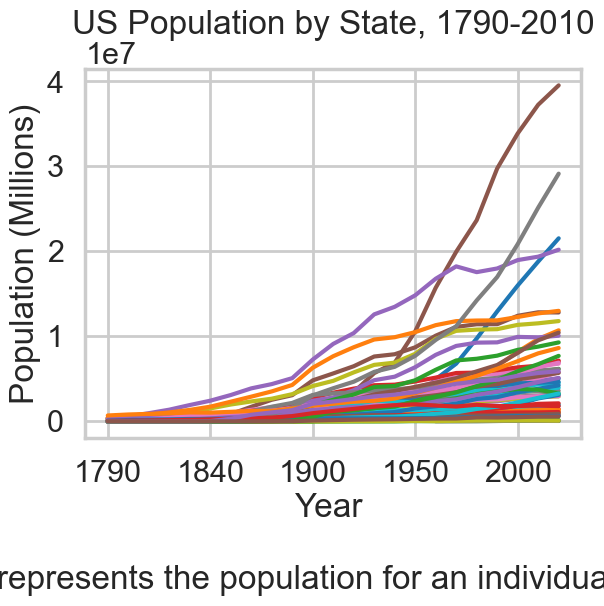

```python
df.T.plot(legend=None)
plt.ylabel("Population (Millions)")
plt.xlabel('Year \n\n (Every line represents the population for an individual state overtime)')
plt.title("US Population by State, 1790-2010")
```

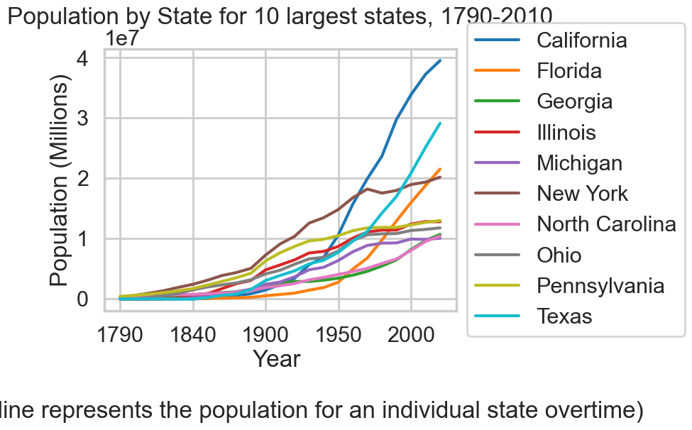

```python
# let's look at just the 10 largest states (2010 population)
df.sort_values('2010', ascending=False)
largest = df['2010'].nlargest(10).index
df[df.index.isin(largest)].T.plot()
plt.legend(loc='center left', bbox_to_anchor=(1.0, 0.5))
plt.title("Population by State for 10 largest states, 1790-2010")
plt.ylabel("Population (Millions)")
plt.xlabel('Year \n\n (Every line represents the population for an individual state overtime)')
```

Perhaps it will be more interested to view as percentage of total US population, so we can see relative change overtime…

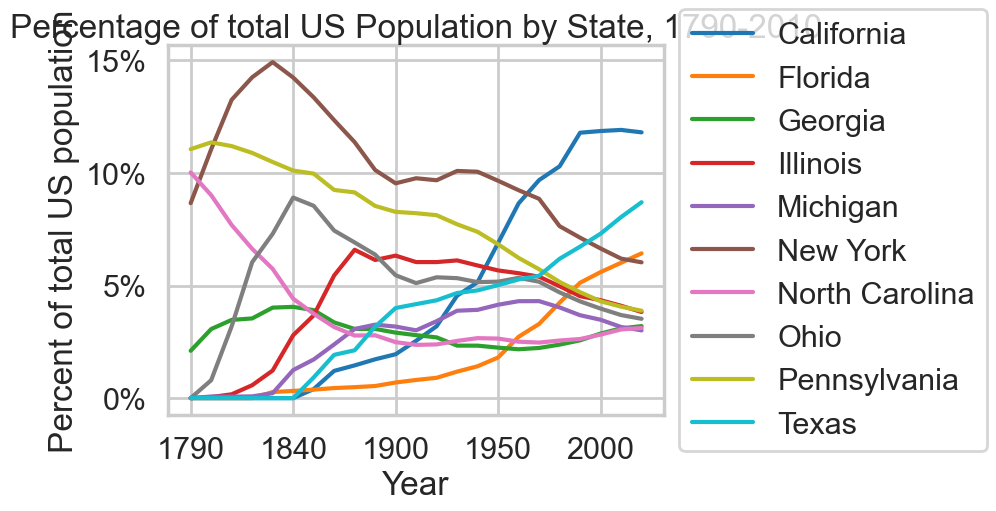

```python
import matplotlib.ticker as mtick
cols = df.columns
by_percent = df[cols].div(df[cols].sum(axis=0), axis=1).multiply(100)
by_percent[by_percent.index.isin(largest)].T.plot()
plt.legend(loc='center left', bbox_to_anchor=(1.0, 0.5))
plt.ylabel("Percent of total US population")
plt.xlabel("Year")
plt.title("Percentage of total US Population by State, 1790-2010")

# Make y-axis percentages
ax = plt.gca()
fmt = '%.0f%%' # Format you want the ticks, e.g. '40%'
yticks = mtick.FormatStrFormatter(fmt)
ax.yaxis.set_major_formatter(yticks)
```

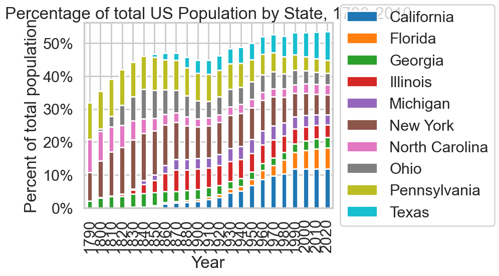

```python
by_percent[by_percent.index.isin(largest)].T.plot(kind="bar",stacked=True)
plt.legend(loc='center left', bbox_to_anchor=(1.0, 0.5))
plt.ylabel("Percent of total population")
plt.xlabel("Year")
plt.title("Percentage of total US Population by State, 1790-2010")

ax = plt.gca()
ax.yaxis.set_major_formatter(yticks)
```